# Differential Analysis part2

You Zhou

May 3, 2021

# Introduction

Differential expression analysis means taking the normalized read count data and performing statistical analysis to discover quantitative changes in expression levels between experimental groups. For example, we use statistical testing to decide whether, for a given gene, an observed difference in read counts is significant, that is, whether it is greater than what would be expected just due to natural random variation.

For a normal workflow, we need to first map the reads. Then we will do the counting step. After the counting step we can do the differential gene expression analysis with the tool like `edgeR` or `DESeq2`.

This coding tasks is the follow-up to the [coding task on 04.03.2021](https://github.com/ZarnackGroup/Zarnack_CodingTasks/tree/master/2021_03_04_DESeq2%20part%201). In this coding task, we will again focus on the downstream analysis for the RNAseq data. For solving the questions in this coding task, the following packages are recommended.

```r
## Load the suggested packages
library(DESeq2)
library(dplyr)
library(ggplot2)
library(biomaRt)
library(clusterProfiler)
```

# Tasks

For solving the following questions, you need to first load the data set `test_DESeq_data.rds`. Moreover, this data is a `DESeqDataSet`.

```r
dds <- readRDS("/Users/codezy/Desktop/Project/coding task/04.03.2021 Differential Analysis/rds/test_DESeq_data.rds")
```

## Task1

How can we get the normalized read counts from a `DESeqDataSet`?

```r
norm_df <- counts(dds, normalized=TRUE)
```

## Task2

Making the normalized counts plot for gene `ENSMUSG00000082365.2` and `ENSMUSG00000002233.13`.

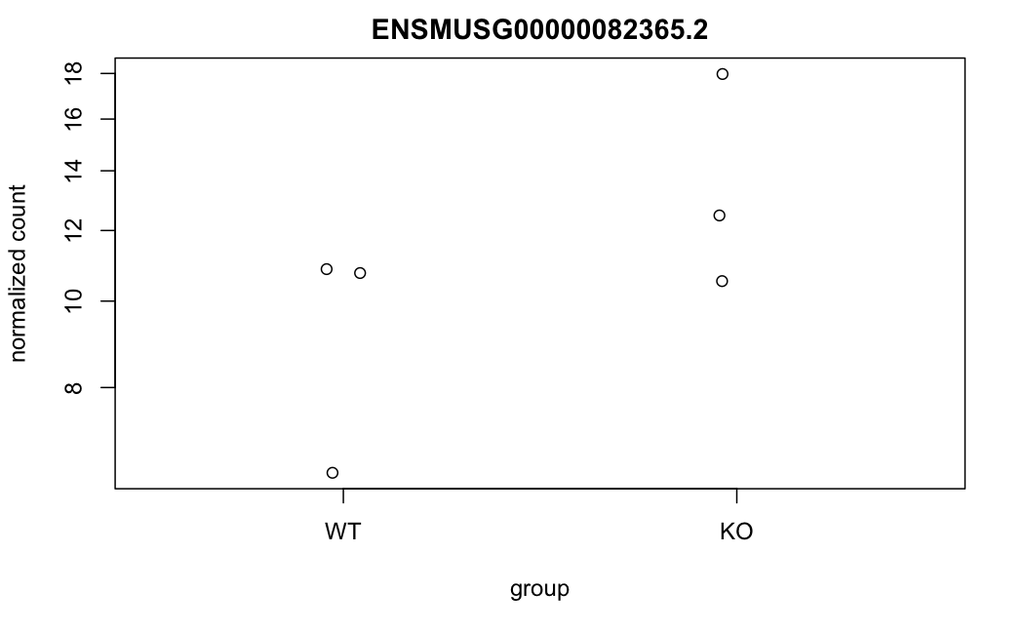

```r
plotCounts(dds, gene = "ENSMUSG00000082365.2", normalized = TRUE)
```

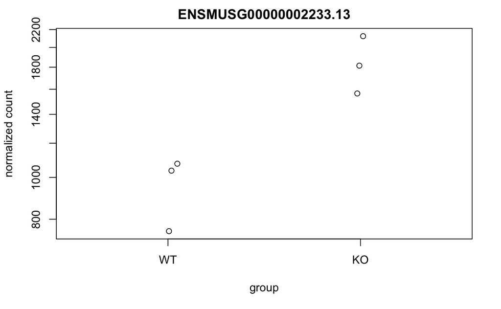

```r
plotCounts(dds, gene = "ENSMUSG00000002233.13", normalized = TRUE)
```

## Task3

```r
## The altHypothesis would be useful here
res_greater <- results(dds, contrast=c("condition","KO","WT"), lfcThreshold=0.2,
                       altHypothesis="greaterAbs")
sig_res_greater <- res_greater[which(res_greater$padj <= 0.05),] %>% as.data.frame()
```

## Task4

Using the package [`bioMart`](https://bioconductor.org/packages/release/bioc/html/biomaRt.html) to get the `gene names`, `entrez_id` and `gene_id` for both the significantly up and down regulated genes in the `Task3`.

**Tips**: The species of this data set is mouse (Mus musculus).

```r
## for using the bioMart we need to first set the useMart
mart <- useMart("ENSEMBL_MART_ENSEMBL", dataset = "mmusculus_gene_ensembl",
        host = "sep2019.archive.ensembl.org", path = "/biomart/martservice",
        archive = FALSE)

geneids_up <- substr(rownames(sig_res_greater[sig_res_greater$log2FoldChange > 0,]), 1, 18)
geneids_down <- substr(rownames(sig_res_greater[sig_res_greater$log2FoldChange < 0,]), 1, 18)
all_genes <- substr(rownames(res_greater), 1, 18)

df_id_sig_up <- getBM(attributes = c('ensembl_gene_id', 'external_gene_name', 'entrezgene_id'),
                      filters = 'ensembl_gene_id', values = geneids_up, mart = mart)
df_id_sig_down <- getBM(attributes = c('ensembl_gene_id', 'external_gene_name', 'entrezgene_id'),
                        filters = 'ensembl_gene_id', values = geneids_down, mart = mart)
df_all_genes <- getBM(attributes = c('ensembl_gene_id', 'external_gene_name', 'entrezgene_id'),
                filters = 'ensembl_gene_id', values = all_genes, mart = mart)
```

## Task5

Do these up and down-regulated genes enrich in any specific `Biological Process` (BP)?

**Tips**: The package [`clusterProfiler`](https://bioconductor.org/packages/release/bioc/html/clusterProfiler.html) may help.

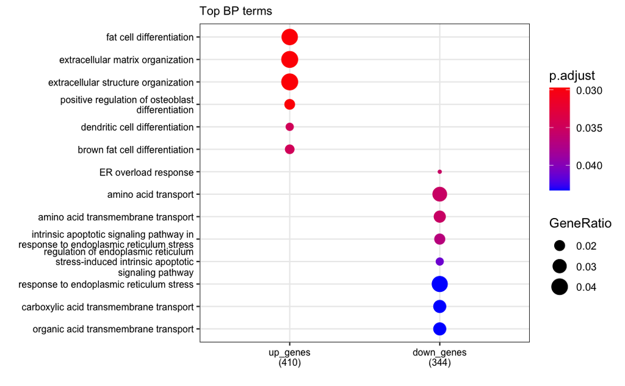

```r
l <- list(up_genes = df_id_sig_up$entrezgene_id,
          down_genes = df_id_sig_down$entrezgene_id)
x <- compareCluster(l, OrgDb='org.Mm.eg.db',fun="enrichGO",
                    pvalueCutoff = 0.05, ont="BP", readable=T,
                    universe = df_all_genes$entrezgene_id)

library(stringr)
clusterProfiler::dotplot(x, showCategory=12, font.size = 8) +
    ggtitle("Top BP terms") +
    scale_y_discrete(labels=function(x) str_wrap(x, width=40)) +
    theme(plot.title = element_text(size=10))
```

## Task6

Making a emapplot for the regulated genes.

**Tips**: function `emapplot` can make this type of plot.

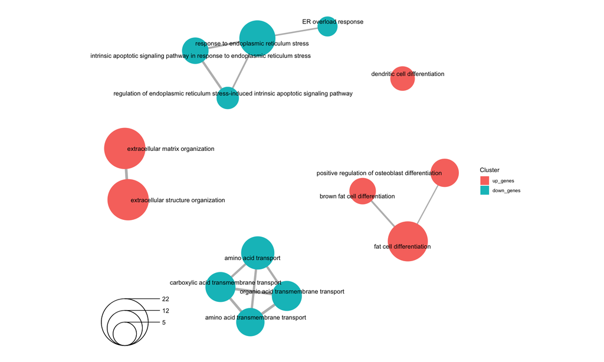

```r
emapplot(x)
```

## Task7

Finding out the KEGG pathway enrichment for the up and down regulated genes and visualizing the result.

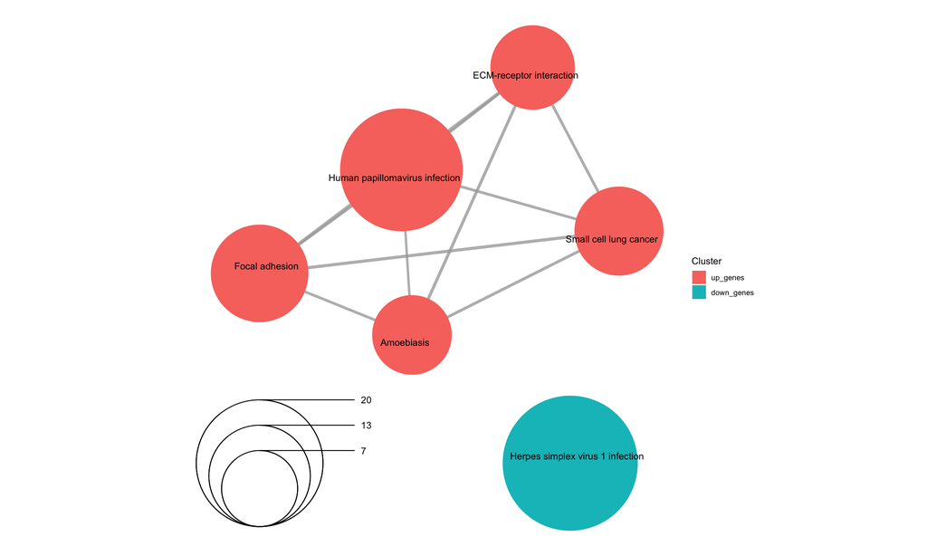

```r
kegg_up <- enrichKEGG(gene         = df_id_sig_up$entrezgene_id,
                      organism     = 'mmu',
                      pvalueCutoff = 0.05)

x2 <- compareCluster(l, fun = "enrichKEGG", organism = 'mmu',
                     pvalueCutoff = 0.05,
                     universe = df_all_genes$entrezgene_id)

emapplot(x2, layout = "kk")
```

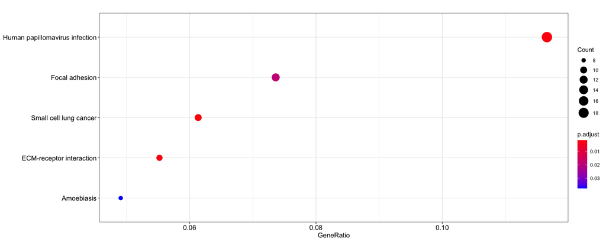

```r
dotplot(kegg_up)
```

```r
browseKEGG(kegg_up, 'mmu05222')
```

**Additional information**: Besides the normal visualization method, such as `dotplot`, `barplot` and so on. With the function `browseKEGG` we can visualize the specific pathway and gets more detail information. Here is [another useful website tool](http://www.fgvis.com/expressvis/importData) which may help you to analysis the RNAseq data.